# LLM Performance Analysis

## Introduction

### Dataset Link

This project is based on a dataset comparing large language models (LLMs), which can be accessed here:

- **[LLM Comparison Dataset](https://www.kaggle.com/datasets/samayashar/large-language-models-comparison-dataset)**

### Dataset Description

This dataset contains performance, cost, and efficiency data for 200 large language models (LLMs) from different providers. It includes both proprietary and open-source models.

#### Key Variables:

| Column | Description |
| --- | --- |
| `Model` | Name of the LLM (e.g., GPT-4, Claude) |
| `Provider` | Organization behind the model |
| `Context Window` | Number of tokens accepted in one prompt |
| `Speed (tokens/sec)` | Token generation speed |
| `Latency (sec)` | Time to first token |
| `Benchmark (MMLU)` | Model performance on MMLU benchmark |
| `Benchmark (Chatbot Arena)` | Community-based performance evaluation |
| `Open-Source` | 1 = Open-source, 0 = Proprietary |
| `Price / Million Tokens` | Cost to use the model per million tokens |
| `Training Dataset Size` | Size of training data used |
| `Compute Power` | Normalized compute used for training |
| `Energy Efficiency` | Score for model energy usage |
| `Quality Rating` | User/Expert rating for quality (1–3) |
| `Speed Rating` | Speed rating (1–3) |
| `Price Rating` | Cost-effectiveness (1–3) |

### Summary Statistics

- **Context Window:** Mean ≈ 637,180 tokens (min: 128,000; max: 2,000,000)
- **Speed:** Mean ≈ 163 tokens/sec
- **Latency:** Mean ≈ 9.36 sec (min: 0.6; max: 19.8)
- **MMLU Benchmark Score:** Mean ≈ 77.9 (range: 60–94)
- **Price:** Mean ≈ $14.47 per million tokens (range: $0.20 – $29.89)
- **Open Source Models:** ~49% of entries

### Dataset Modifications

- I am not removing any rows or filtering the dataset. The data seems cleans in its original state.

## Question 1: Which LLM providers demonstrate the highest and most consistent MMLU benchmark performance?

### Hypothesis:

Some providers consistently outperform others in benchmark evaluations. We expect industry leaders like OpenAI and Anthropic to show both high average scores and low variability in their MMLU performance.

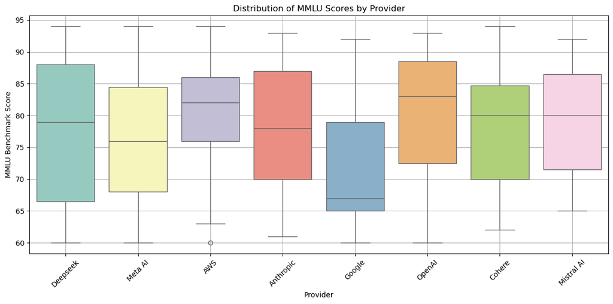

```python
import seaborn as sns
import matplotlib.pyplot as plt
import pandas as pd

df = pd.read_csv("llm_comparison_dataset.csv")

# Unique colors per provider
unique_providers = df["Provider"].unique()
palette_provider = dict(zip(unique_providers, sns.color_palette("Set3", len(unique_providers))))

plt.figure(figsize=(12, 6))
sns.boxplot(data=df, x="Provider", y="Benchmark (MMLU)", hue="Provider", palette=palette_provider, legend=False)
plt.title("Distribution of MMLU Scores by Provider")
plt.ylabel("MMLU Benchmark Score")
plt.xlabel("Provider")
plt.xticks(rotation=45)
plt.grid(True)
plt.tight_layout()
plt.show()
```

## Question 2: Do open-source models perform comparably to proprietary ones?

### Hypothesis: Open-source models are typically less performant and less efficient than proprietary ones.

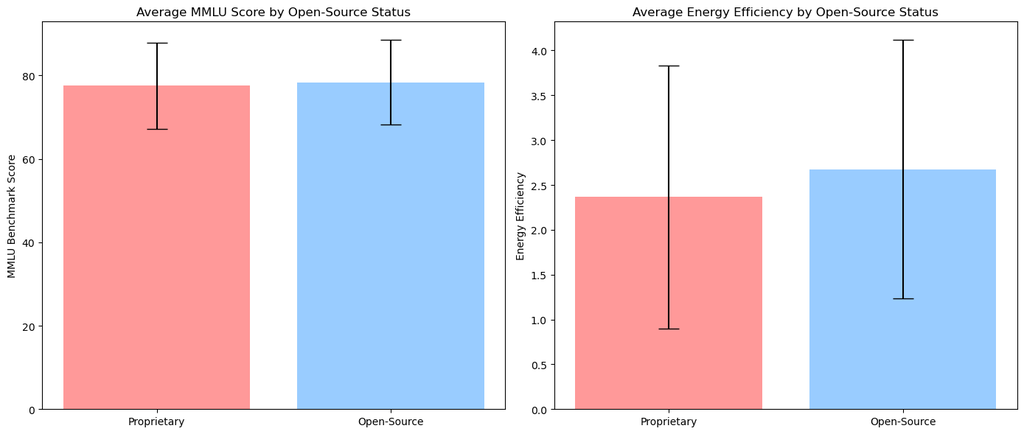

```python
import numpy as np

# Group by Open-Source and calculate mean and std
grouped_stats = df.groupby('Open-Source')[['Benchmark (MMLU)', 'Energy Efficiency']].agg(['mean', 'std'])

# Labels and plot setup
labels = ['Proprietary', 'Open-Source']
x = np.arange(len(labels))
width = 0.6
colors_os = ['#FF9999', '#99CCFF']

fig, axs = plt.subplots(1, 2, figsize=(14, 6))

# MMLU Plot
axs[0].bar(x, grouped_stats['Benchmark (MMLU)']['mean'],
           yerr=grouped_stats['Benchmark (MMLU)']['std'],
           color=colors_os, capsize=10)
axs[0].set_title("Average MMLU Score by Open-Source Status")
axs[0].set_xticks(x)
axs[0].set_xticklabels(labels)
axs[0].set_ylabel("MMLU Benchmark Score")

# Energy Efficiency Plot
axs[1].bar(x, grouped_stats['Energy Efficiency']['mean'],
           yerr=grouped_stats['Energy Efficiency']['std'],
           color=colors_os, capsize=10)
axs[1].set_title("Average Energy Efficiency by Open-Source Status")
axs[1].set_xticks(x)
axs[1].set_xticklabels(labels)
axs[1].set_ylabel("Energy Efficiency")

plt.tight_layout()
plt.show()
```

### Interpretation & Hypothesis Evaluation

These bar plots clearly show that **open-source models perform just as well or better** than proprietary models on average:

- **Benchmark (MMLU):** Open-source models have a slightly **higher average score** (78.37 vs. 77.54), with nearly identical standard deviations.
- **Energy Efficiency:** Open-source models also lead here, with an average of **2.68** compared to **2.37** for proprietary models.

This directly addresses the hypothesis and **challenges the assumption** that proprietary models are superior. Despite fewer resources, open-source models demonstrate **competitive performance and better efficiency**, suggesting they are both viable and scalable alternatives in the LLM space.

## Machine Learning – Regression

### Objective

Fit a regression model to predict a **quantitative variable** in the dataset — in this case, the `Benchmark (MMLU)` score — using other available features.

### Independent & Dependent Variables

- **Dependent Variable (y):**  
  `Benchmark (MMLU)` — a continuous metric representing LLM performance on the MMLU benchmark.
- **Independent Variables (X):**
  - Raw features:  
    `Context Window`, `Speed (tokens/sec)`, `Latency (sec)`, `Open-Source`,  
    `Price / Million Tokens`, `Compute Power`, `Energy Efficiency`,  
    `Benchmark (Chatbot Arena)`, `Quality Rating`, `Speed Rating`, `Price Rating`,  
    One-hot encoded provider columns.
  - Engineered features:
    - `Log Training Size` = log of training dataset size
    - `Cost Efficiency` = price per million tokens ÷ speed

### Models Used

I tested two regression models:

- **Baseline Model:**  
  Gradient Boosting Regressor with default hyperparameters  
  (`n_estimators=200`, `learning_rate=0.1`, `max_depth=3`)
- **Tuned Model:**  
  Gradient Boosting Regressor with hyperparameters selected using GridSearchCV

```python
import pandas as pd
from sklearn.ensemble import GradientBoostingRegressor
from sklearn.model_selection import GridSearchCV, train_test_split
from sklearn.preprocessing import StandardScaler
from sklearn.metrics import r2_score, root_mean_squared_error

# Step 1: Feature engineering
df_gb = df.copy()
df_gb["Log Training Size"] = np.log(df_gb["Training Dataset Size"])
df_gb["Cost Efficiency"] = df_gb["Price / Million Tokens"] / df_gb["Speed (tokens/sec)"]
df_gb = pd.get_dummies(df_gb, columns=['Provider'], drop_first=True) # one-hot encode

# Step 2: Define features and target
extended_features = [
    'Context Window','Speed (tokens/sec)','Latency (sec)','Open-Source',
    'Price / Million Tokens','Compute Power','Energy Efficiency',
    'Log Training Size','Cost Efficiency','Benchmark (Chatbot Arena)',
    'Quality Rating','Speed Rating','Price Rating'
] + [c for c in df_gb if c.startswith('Provider_')]

X = df_gb[extended_features]
y = df_gb["Benchmark (MMLU)"]

# Step 3: Scale features
scaler = StandardScaler()
X_scaled = scaler.fit_transform(X)

# Step 4: Train-test split
X_train, X_test, y_train, y_test = train_test_split(X_scaled, y, test_size=0.2, random_state=42)

# ------------------------
# Baseline GB Regressor
# ------------------------
baseline_gb = GradientBoostingRegressor(n_estimators=200, learning_rate=0.1, max_depth=3, random_state=42)
baseline_gb.fit(X_train, y_train)
y_pred_base = baseline_gb.predict(X_test)

# Evaluation
r2_base = r2_score(y_test, y_pred_base)
rmse_base = root_mean_squared_error(y_test, y_pred_base)

# Feature importances (baseline)
importances_base = pd.Series(baseline_gb.feature_importances_, index=extended_features)

print("Baseline Gradient Boosting R²:", r2_base)
print("Baseline Gradient Boosting RMSE:", rmse_base)
print("\nTop 10 Baseline Feature Importances:\n", importances_base.sort_values(ascending=False).head(10))

# -------------------------------
# Tuned GB Regressor (GridSearch)
# -------------------------------
param_grid = {
    'n_estimators': [100, 200, 300],
    'learning_rate': [0.05, 0.1, 0.2],
    'max_depth': [3, 5, 7]
}
grid = GridSearchCV(GradientBoostingRegressor(random_state=42), param_grid, cv=5, scoring='r2', n_jobs=-1)
grid.fit(X_train, y_train)

# Use best model from grid search
best_gb = grid.best_estimator_
y_pred_best = best_gb.predict(X_test)

# Evaluation
r2_tuned = r2_score(y_test, y_pred_best)
rmse_tuned = root_mean_squared_error(y_test, y_pred_best)

# Feature importances (tuned)
importances_tuned = pd.Series(best_gb.feature_importances_, index=extended_features)

print("\nBest Hyperparameters:", grid.best_params_)
print("Best CV R²:", grid.best_score_)
print("\nTuned Gradient Boosting R²:", r2_tuned)
print("Tuned Gradient Boosting RMSE:", rmse_tuned)
print("\nTop 10 Tuned Feature Importances:\n", importances_tuned.sort_values(ascending=False).head(10))
```

```
Baseline Gradient Boosting R²: 0.8443780194714157
Baseline Gradient Boosting RMSE: 4.177388361504706

Top 10 Baseline Feature Importances:
 Quality Rating               0.884829
Compute Power                0.019834
Latency (sec)                0.018254
Benchmark (Chatbot Arena)    0.016989
Speed (tokens/sec)           0.012497
Cost Efficiency              0.012286
Price / Million Tokens       0.011097
Energy Efficiency            0.009564
Log Training Size            0.006427
Provider_Mistral AI          0.003593
dtype: float64

Best Hyperparameters: {'learning_rate': 0.05, 'max_depth': 3, 'n_estimators': 100}
Best CV R²: 0.8418110467375925

Tuned Gradient Boosting R²: 0.865223719090694
Tuned Gradient Boosting RMSE: 3.887551160382261

Top 10 Tuned Feature Importances:
 Quality Rating               0.916337
Latency (sec)                0.014218
Benchmark (Chatbot Arena)    0.013877
Compute Power                0.013838
Cost Efficiency              0.009832
Price / Million Tokens       0.008524
Speed (tokens/sec)           0.007892
Energy Efficiency            0.006664
Provider_Mistral AI          0.003996
Log Training Size            0.003690
dtype: float64
```

### Evaluation Results

| Model | R² Score | RMSE |
| --- | --- | --- |
| **Baseline** | 0.844 | 4.18 |
| **Tuned** | **0.865** | **3.89** |

- **Best Parameters (Tuned):**  
  `n_estimators=100`, `learning_rate=0.05`, `max_depth=3`
- **Best Cross-Validation R²:** 0.842

### Interpretation of Results

- The tuned Gradient Boosting model **explains ~86.5% of the variance** in MMLU scores and shows a **low prediction error** (~3.89 RMSE).
- The model is **well-generalized** — there is no indication of overfitting or underfitting, as cross-validation and test performance are nearly identical
- **Top Predictive Features (Tuned Model):**
  1. `Quality Rating` — overwhelmingly dominant
  2. `Latency (sec)` and `Benchmark (Chatbot Arena)`
  3. `Compute Power`, `Cost Efficiency`, `Price / Million Tokens`

### Recommendation

- I **recommend the tuned Gradient Boosting model** for future benchmark prediction tasks.
- Its accuracy and interpretability make it well-suited for estimating performance in LLM deployment and selection pipelines.

## Machine Learning – Classification

### Objective

Train a machine learning model to predict a **categorical** variable — specifically, whether a large language model (LLM) is **open-source (1)** or **proprietary (0)** — based on features such as cost, speed, efficiency, and benchmark performance.

### Independent and Dependent Variables

- **Dependent Variable (Target):**  
  `Open-Source` — binary indicator:
  - `1` = Open-Source
  - `0` = Proprietary
- **Independent Variables (Features):**
  - `Context Window`, `Speed (tokens/sec)`, `Latency (sec)`
  - `Price / Million Tokens`, `Training Dataset Size`, `Compute Power`, `Energy Efficiency`
  - `Benchmark (MMLU)`, `Benchmark (Chatbot Arena)`
  - `Quality Rating`, `Speed Rating`, `Price Rating`
  - One-hot encoded provider columns

### Model Used: Random Forest Classifier

I chose a **Random Forest Classifier** due to its strong performance on tabular datasets, ability to capture non-linear patterns, and interpretability via feature importance. We used the default hyperparameters with 100 trees.

```
Random Forest Training Accuracy: 1.0
Random Forest Test Accuracy: 0.6

Confusion Matrix:
 [[13  9]
 [ 7 11]]

Classification Report:
               precision    recall  f1-score   support

           0       0.65      0.59      0.62        22
           1       0.55      0.61      0.58        18

    accuracy                           0.60        40
   macro avg       0.60      0.60      0.60        40
weighted avg       0.61      0.60      0.60        40
```

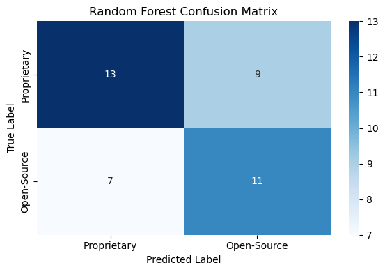

```python
import pandas as pd
from sklearn.ensemble import RandomForestClassifier
from sklearn.model_selection import train_test_split
from sklearn.metrics import accuracy_score, confusion_matrix, classification_report
import seaborn as sns
import matplotlib.pyplot as plt

# Step 1: Load and prepare the dataset
df = pd.read_csv('llm_comparison_dataset.csv')

# One-hot encode the Provider column
df = pd.get_dummies(df, columns=['Provider'], drop_first=True)

# Step 2: Define features and target
features = [
    'Context Window','Speed (tokens/sec)','Latency (sec)',
    'Price / Million Tokens','Training Dataset Size','Compute Power',
    'Energy Efficiency','Benchmark (MMLU)','Benchmark (Chatbot Arena)',
    'Quality Rating','Speed Rating','Price Rating'
] + [col for col in df.columns if col.startswith('Provider_')]

X = df[features]
y = df["Open-Source"]

# Step 3: Train-test split
X_train, X_test, y_train, y_test = train_test_split(
    X, y, test_size=0.2, random_state=42
)

# Step 4: Train the Random Forest classifier
rf = RandomForestClassifier(n_estimators=100, random_state=42)
rf.fit(X_train, y_train)

# Step 5: Evaluate the model
y_train_pred = rf.predict(X_train)
y_test_pred = rf.predict(X_test)

train_acc = accuracy_score(y_train, y_train_pred)
test_acc = accuracy_score(y_test, y_test_pred)
cm = confusion_matrix(y_test, y_test_pred)
report = classification_report(y_test, y_test_pred)

print("Random Forest Training Accuracy:", train_acc)
print("Random Forest Test Accuracy:", test_acc)
print("\nConfusion Matrix:\n", cm)
print("\nClassification Report:\n", report)

# Step 6: Plot the confusion matrix heatmap
plt.figure(figsize=(6, 4))
sns.heatmap(cm, annot=True, fmt='d', cmap='Blues',
            xticklabels=['Proprietary', 'Open-Source'],
            yticklabels=['Proprietary', 'Open-Source'])
plt.title('Random Forest Confusion Matrix')
plt.xlabel('Predicted Label')
plt.ylabel('True Label')
plt.tight_layout()
plt.show()
```

### Evaluation

- **Training Accuracy:** 1.00
- **Test Accuracy:** 0.60
- **Confusion Matrix:**

### Interpretation

- The model **perfectly fits the training set** but achieves only **60% accuracy** on the test set, indicating **overfitting**.
- Both precision and recall are balanced across the two classes, with slightly better precision for class 0 (Proprietary) and better recall for class 1 (Open-Source).
- The confusion matrix shows that the model misclassifies a significant number of examples in both classes.

### Recommendation

- The **Random Forest Classifier** achieves a moderate level of predictive performance.
- Due to the **overfitting** (100% train vs. 60% test accuracy), the model would benefit from regularization, such as setting `max_depth` or `min_samples_split`. However, tuning attempts (e.g., max_depth=5) led to reduced accuracy.
- This model is **adequate for exploratory analysis** but would require refinement or additional data to be production-ready.
- At this point, I would not recommend this model to be used for prediction in the future.

## Ethical Considerations

While the dataset does not contain personally identifiable information or sensitive data, there are still several ethical dimensions worth addressing:

### Respect for Persons

- The dataset includes performance and efficiency comparisons of commercial and open-source LLMs. It's important to ensure that interpretations remain **fair and objective**, avoiding assumptions about superiority based solely on brand recognition.

### Beneficence

- This analysis contributes to public understanding by **evaluating the performance and efficiency** of LLMs, including open-source alternatives, which supports transparency and innovation.
- However, models with higher performance may still pose risks (e.g., misinformation, bias amplification), and this dataset does not capture ethical usage or safeguards.

### Justice

- Open-source models are shown to be highly competitive. Highlighting this **promotes equitable access** to high-performing LLMs, especially for under-resourced communities or academic institutions.

### Respect for Law and Public Interest

- No proprietary internals or user data are exposed. All performance metrics are at the **model-level**, avoiding intellectual property infringement or misuse of private datasets.

Overall, the dataset supports ethical research, but it's essential to contextualize performance results with the **broader social and regulatory implications** of deploying large-scale AI systems.

## Conclusion

This project explored a comparative analysis of large language models (LLMs) across providers, architectures, and access types using real-world benchmark and performance data.

### Takeaway:

Open-source LLMs are not only viable but **competitive**. While performance benchmarks are important, **accessibility, efficiency, and transparency** are equally critical in shaping the future of responsible AI.

This analysis demonstrates how **data-driven model comparison** can reveal meaningful insights and challenge assumptions in the rapidly evolving LLM landscape.